# Twitter US Airline Sentiment

## Description

**Background and Context:**

Twitter possesses 330 million monthly active users, which allows businesses to reach a broad population and connect with customers without intermediaries. On the other hand, there’s so much information that it’s difficult for brands to quickly detect negative social mentions that could harm their business.

That's why sentiment analysis/classification, which involves monitoring emotions in conversations on social media platforms, has become a key strategy in social media marketing.

Listening to how customers feel about the product/service on Twitter allows companies to understand their audience, keep on top of what’s being said about their brand and their competitors, and discover new trends in the industry.

**Data Description:**

A sentiment analysis job about the problems of each major U.S. airline. Twitter data was scraped from February of 2015 and contributors were asked to first classify positive, negative, and neutral tweets, followed by categorizing negative reasons (such as "late flight" or "rude service").

**Dataset:**

The dataset has the following columns:

tweet_id  
airline_sentiment  
airline_sentiment_confidence  
negativereason  
negativereason_confidence  
airline  
airline_sentiment_gold  
name  
negativereason_gold retweet_count text tweet_coord tweet_created tweet_location user_timezone

**Opinion:** I am neutral when it comes to airlines, I fly often between states and they are all pretty much the same.

Unfortunately the dataset features are not very detailed to explain what they are and how the info was obtained so assumptions will be made on the features (that they are self explanatory) and the data contained in them.

## **Import the libraries, load dataset, print the shape of data, data description.**

### **Libraries**

```python
import warnings
warnings.filterwarnings("ignore")

from google.colab import drive
# # Read in CSV into browser. Not using for sumbission
# from google.colab import files

import matplotlib.pyplot as plt , seaborn as sns
import numpy as np , pandas as pd
from sklearn.model_selection import train_test_split
```

```python
from bs4 import BeautifulSoup
import re
import string
import unicodedata
import wordcloud

# Had to leave the pip each time. Not sure why Colab doesn't retain it.
!pip install contractions
import contractions

from nltk.corpus import stopwords
from nltk.stem.wordnet import WordNetLemmatizer
import nltk
nltk.download('stopwords')
nltk.download('punkt')

from nltk.stem.porter import PorterStemmer
nltk.download('wordnet')
```

```
True
```

```python
from sklearn.feature_extraction.text import CountVectorizer
from sklearn.feature_extraction.text import TfidfVectorizer

from sklearn.ensemble import RandomForestClassifier

from sklearn import metrics
from sklearn.model_selection import cross_val_score
from sklearn.metrics import confusion_matrix
from wordcloud import WordCloud
```

### Load Dataset

```python
drive.mount('/content/drive')
filepath ="/content/drive/My Drive/Colab Notebooks/GL - University of Texas at Austin/08 - NLP_w3 Project/"
tweet_data_raw = pd.read_csv(filepath+"Tweets.csv")
```

### Print the shape of data

```python
print("Shape of the data is:",tweet_data_raw.shape)
```

```
Shape of the data is: (14640, 15)
```

```python
tweet_data_raw.columns
```

```
Index(['tweet_id', 'airline_sentiment', 'airline_sentiment_confidence',
       'negativereason', 'negativereason_confidence', 'airline',
       'airline_sentiment_gold', 'name', 'negativereason_gold',
       'retweet_count', 'text', 'tweet_coord', 'tweet_created',
       'tweet_location', 'user_timezone'],
      dtype='object')
```

```python
tweet_data_raw.head(5)
```

|  | tweet_id | airline_sentiment | airline_sentiment_confidence | negativereason | negativereason_confidence | airline | airline_sentiment_gold | name | negativereason_gold | retweet_count | text | tweet_coord | tweet_created | tweet_location | user_timezone |
| --- | --- | --- | --- | --- | --- | --- | --- | --- | --- | --- | --- | --- | --- | --- | --- |
| 0 | 570306133677760513 | neutral | 1.0000 | NaN | NaN | Virgin America | NaN | cairdin | NaN | 0 | @VirginAmerica What @dhepburn said. | NaN | 2015-02-24 11:35:52 -0800 | NaN | Eastern Time (US & Canada) |
| 1 | 570301130888122368 | positive | 0.3486 | NaN | 0.0000 | Virgin America | NaN | jnardino | NaN | 0 | @VirginAmerica plus you've added commercials t... | NaN | 2015-02-24 11:15:59 -0800 | NaN | Pacific Time (US & Canada) |
| 2 | 570301083672813571 | neutral | 0.6837 | NaN | NaN | Virgin America | NaN | yvonnalynn | NaN | 0 | @VirginAmerica I didn't today... Must mean I n... | NaN | 2015-02-24 11:15:48 -0800 | Lets Play | Central Time (US & Canada) |
| 3 | 570301031407624196 | negative | 1.0000 | Bad Flight | 0.7033 | Virgin America | NaN | jnardino | NaN | 0 | @VirginAmerica it's really aggressive to blast... | NaN | 2015-02-24 11:15:36 -0800 | NaN | Pacific Time (US & Canada) |
| 4 | 570300817074462722 | negative | 1.0000 | Can't Tell | 1.0000 | Virgin America | NaN | jnardino | NaN | 0 | @VirginAmerica and it's a really big bad thing... | NaN | 2015-02-24 11:14:45 -0800 | NaN | Pacific Time (US & Canada) |

**Observations & Insights:**

Primary columns of interest 'airline_sentiment' , 'airline' , 'text', 'retweet_count' , 'tweet_created'

I don't trust the sentiment confidence and airline_sentiment as those appear to possibly be manually entered

tweet_id looks like a primary key for the database

### Data Description

```python
# Dropping Tweet Unique Identifier, Primary Key to be left out of the .describe()
tweet_data_raw.drop(['tweet_id'],axis=1, inplace=True)
```

```python
tweet_data_raw.describe()
```

|  | airline_sentiment_confidence | negativereason_confidence | retweet_count |
| --- | --- | --- | --- |
| count | 14640.000000 | 10522.000000 | 14640.000000 |
| mean | 0.900169 | 0.638298 | 0.082650 |
| std | 0.162830 | 0.330440 | 0.745778 |
| min | 0.335000 | 0.000000 | 0.000000 |
| 25% | 0.692300 | 0.360600 | 0.000000 |
| 50% | 1.000000 | 0.670600 | 0.000000 |
| 75% | 1.000000 | 1.000000 | 0.000000 |
| max | 1.000000 | 1.000000 | 44.000000 |

**Observations & Insights:**

Retweet might be the only one thats kind of interesting but even that is poor for statistical analysis. What we can tell is that there seems to be misisng data in negativereason_confidence which may indicate a complete data entry.

### **EDA**

#### **Part A:** Plot the distribution of all tweets among each airline & plot the distribution of sentiment across all the tweets

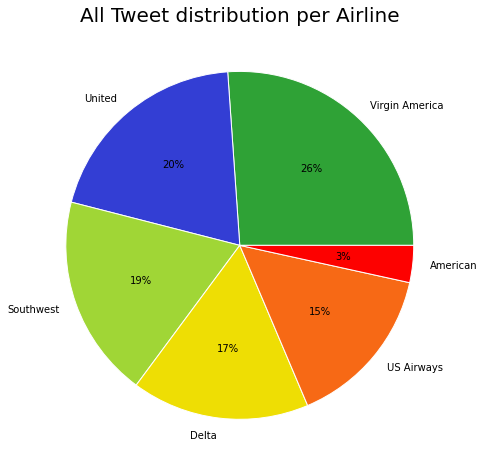

```python
# Setting MatPlotLib embelishments
colors = [ "#2FA236"  ,"#333ED4"  ,"#A0D636"  ,"#EEDE04"  ,"#F76915"  ,"#FD0100"]
wedge  = { 'linewidth' : 1, 'edgecolor' : 'white' }

# Plotting Distributions
airlines = tweet_data_raw['airline'].unique()
piece= tweet_data_raw['airline'].value_counts()

pie, ax = plt.subplots(figsize=[8,8])
plt.pie(x = piece,labels = airlines,autopct = "%.0f%%",wedgeprops = wedge,colors = colors)
plt.title("All Tweet distribution per Airline", fontsize=20);
```

**Observations & Insights:**

The distribution of the others ranges from 15% to 26%, with the average at about 19%.

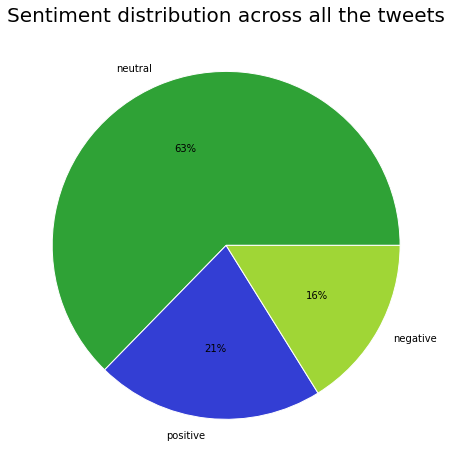

```python
#2A Using matplotlib to draw piechart of labels
airlines = tweet_data_raw['airline_sentiment'].unique()
piece= tweet_data_raw['airline_sentiment'].value_counts()

pie, ax = plt.subplots(figsize=[8,8])
plt.pie(x = piece, labels = airlines, autopct = "%.0f%%",wedgeprops = wedge,colors = colors)
plt.title("Sentiment distribution across all the tweets", fontsize=20);
```

**Observations & Insights:**

#### **Part B:** Plot the distribution of Sentiment of tweets for each airline & plot the distribution of all the negative reasons.

##### Functions

```python
# Function to plot the sentiment of the dataframe with the sentiment
def plotTweetSentiment(df, sentiment):
  # DataFrame created for visual
  plotTweetSenti = pd.DataFrame(columns=['Counts', 'Airlines'] )

  # get a roster of the different airlines
  airlines_roster = df['airline'].unique()
  # get the sentiment into its own list
  sentiment = df[df['airline_sentiment']==sentiment]

  # Cycle through the airlines and count the sentiments  then add to table
  for i in range(0,airlines_roster.size):
    # count the sentiments
    tally = sentiment[sentiment['airline'] == airlines_roster[i]].count()['airline_sentiment']
    # 'insert' count and airline into table the print it
    plotTweetSenti.loc[i] = [tally, airlines_roster[i]]
    print (tally," ",airlines_roster[i])

  # return barplot with dataframe created & inserted/appended to
  return sns.barplot(data=plotTweetSenti , x='Airlines', y='Counts')
```

```
152   Virgin America
492   United
570   Southwest
544   Delta
269   US Airways
336   American
```

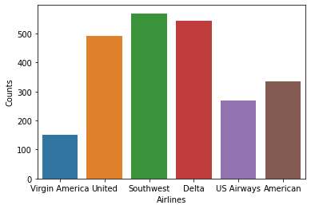

```python
plotTweetSentiment( tweet_data_raw , 'positive')
```

**Observations & Insights:**

The airlines most positive tweets in this data sample are United, Southwest Airlines, and Delta. The one with the least is Virgin America.

```
171   Virgin America
697   United
664   Southwest
723   Delta
381   US Airways
463   American
```

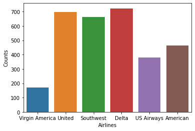

```python
plotTweetSentiment( tweet_data_raw , 'neutral')
```

**Observations & Insights:**

The airlines with the most neutral tweets in this data sample are United, Southwest Airlines, and Delta. The one with the least is Virgin America.

```
181   Virgin America
2633   United
1186   Southwest
955   Delta
2263   US Airways
1960   American
```

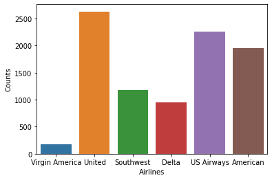

```python
plotTweetSentiment( tweet_data_raw , 'negative')
```

**Observations & Insights:**

The airlines with the most negative tweets in this data sample are United, US Airways and American. The one with the least is Virgin America.

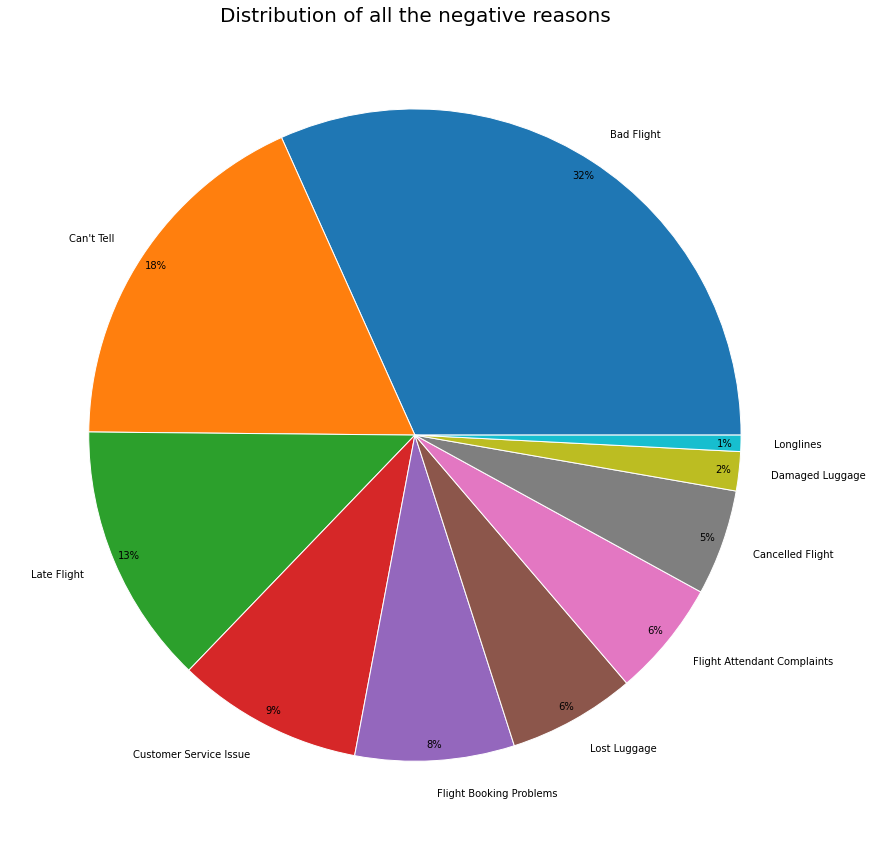

```python
airlines = ['Bad Flight', "Can't Tell", 'Late Flight',
       'Customer Service Issue', 'Flight Booking Problems',
       'Lost Luggage', 'Flight Attendant Complaints', 'Cancelled Flight',
       'Damaged Luggage', 'Longlines']
piece= tweet_data_raw['negativereason'].value_counts()

pie, ax = plt.subplots(figsize=[15,15])
plt.pie(x = piece, labels = airlines, autopct = "%.0f%%", pctdistance=.95,wedgeprops = wedge)
plt.title("Distribution of all the negative reasons", fontsize=20);
```

The least complaints were Longlines, Damaged Luggage.

#### **Part C:** Plot the word cloud graph of tweets for positive and negative sentiment separately.

```python
def show_wordcloud(Positive_sent, title):
    text = ' '.join(Positive_sent['text'].astype(str).tolist())
    stopwords = set(wordcloud.STOPWORDS)

    fig_wordcloud = wordcloud.WordCloud(stopwords=stopwords,background_color='white',
                    colormap='viridis', width=800, height=600).generate(text)

    plt.figure(figsize=(14,11), frameon=True)
    plt.imshow(fig_wordcloud)
    plt.axis('off')
    plt.title(title, fontsize=30)
    plt.show()
```

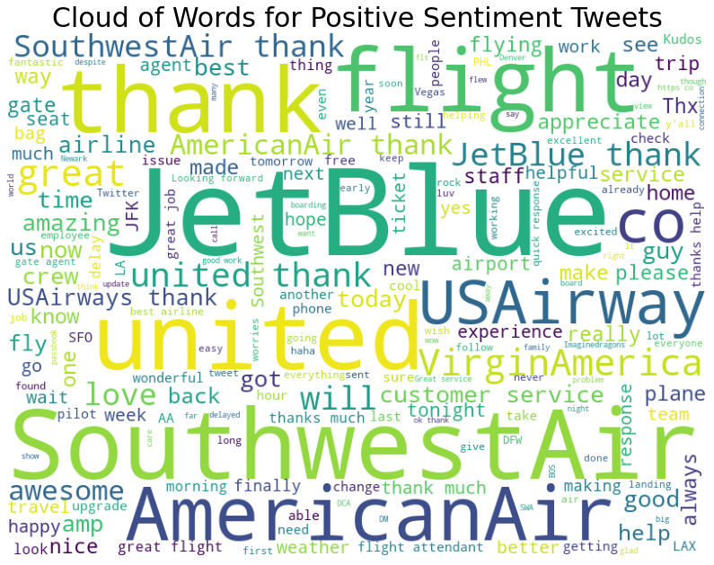

```python
Positive_sent = tweet_data_raw[tweet_data_raw['airline_sentiment']=='positive']
show_wordcloud(Positive_sent, "Cloud of Words for Positive Sentiment Tweets")
```

**Observations & Insights:** JetBlue seems to be a common theme which I believe are partnered with American which is kind of like taking credit by proxy.

A lot of the dominance in in the wordcloud may indicate '@twitterhandle'

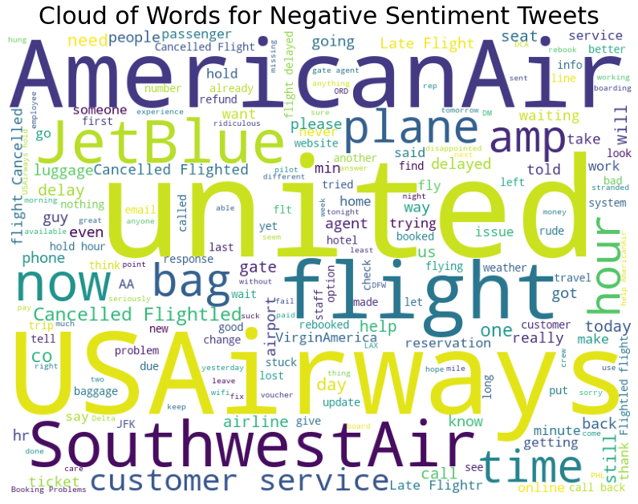

```python
Positive_sent = tweet_data_raw[tweet_data_raw['airline_sentiment']=='negative']
show_wordcloud(Positive_sent, "Cloud of Words for Negative Sentiment Tweets")
```

**Observations & Insights:** USAirways, United, American and seem to be the most comment. As far as reason or topics that show often are bag, time, hour, cancelled flight and customer service.

Here it seems the seem that the dominance in in the wordcloud may indicate '@twitterhandle'

#### Additional EDA

```python
# Most tweeted
MaxTweetDeets = tweet_data_raw.iloc[tweet_data_raw['retweet_count'].idxmax()]
MaxTweeted = MaxTweetDeets ['text']
ReTweetCount = MaxTweetDeets ['retweet_count']


print("Max Retweet was shared", ReTweetCount, "times")
print("Max Retweet was \"",MaxTweeted, "\"")
print()
MaxTweetDeets
```

```
Max Retweet was shared 44 times
Max Retweet was " @USAirways 5 hr flight delay and a delay when we land . Is that even real life ? Get me off this plane , I wanna go home 👠👠👠 (3 heel clicks) "
```

```
airline_sentiment                                                        negative
airline_sentiment_confidence                                                    1
negativereason                                                        Late Flight
negativereason_confidence                                                       1
airline                                                                US Airways
airline_sentiment_gold                                                        NaN
name                                                                        OBJ_3
negativereason_gold                                                           NaN
retweet_count                                                                  44
text                            @USAirways 5 hr flight delay and a delay when ...
tweet_coord                                                                   NaN
tweet_created                                           2015-02-17 20:06:21 -0800
tweet_location                                                                NaN
user_timezone                                          Eastern Time (US & Canada)
Name: 11596, dtype: object
```

**Observations & Insights:**

### **Understand of data columns**

#### **Part A:** Drop all other columns except “text” and “airline_sentiment”.

```python
tweet_data_TEXT_SENTIMENT = tweet_data_raw.filter(items=['airline_sentiment', 'text'])
tweet_data_TEXT_SENTIMENT.columns
```

```
Index(['airline_sentiment', 'text'], dtype='object')
```

#### **Part B:** Check the shape of the data.

```python
print("Size Before dropping all columns but airline_sentiment & text" , tweet_data_raw.shape)
print("Size After  dropping all columns but airline_sentiment & text" , tweet_data_TEXT_SENTIMENT.shape)
```

```
Size Before dropping all columns but airline_sentiment & text (14640, 14)
Size After  dropping all columns but airline_sentiment & text (14640, 2)
```

#### **Part C:** Print the first 5 rows of data.

```python
pd.set_option('display.max_colwidth', None)
tweet_data_TEXT_SENTIMENT.head(15)
```

|  | airline_sentiment | text |
| --- | --- | --- |
| 0 | neutral | @VirginAmerica What @dhepburn said. |
| 1 | positive | @VirginAmerica plus you've added commercials to the experience... tacky. |
| 2 | neutral | @VirginAmerica I didn't today... Must mean I need to take another trip! |
| 3 | negative | @VirginAmerica it's really aggressive to blast obnoxious "entertainment" in your guests' faces &amp; they have little recourse |
| 4 | negative | @VirginAmerica and it's a really big bad thing about it |
| 5 | negative | @VirginAmerica seriously would pay $30 a flight for seats that didn't have this playing.\nit's really the only bad thing about flying VA |
| 6 | positive | @VirginAmerica yes, nearly every time I fly VX this “ear worm” won’t go away :) |
| 7 | neutral | @VirginAmerica Really missed a prime opportunity for Men Without Hats parody, there. https://t.co/mWpG7grEZP |
| 8 | positive | @virginamerica Well, I didn't…but NOW I DO! :-D |
| 9 | positive | @VirginAmerica it was amazing, and arrived an hour early. You're too good to me. |
| 10 | neutral | @VirginAmerica did you know that suicide is the second leading cause of death among teens 10-24 |
| 11 | positive | @VirginAmerica I &lt;3 pretty graphics. so much better than minimal iconography. :D |
| 12 | positive | @VirginAmerica This is such a great deal! Already thinking about my 2nd trip to @Australia &amp; I haven't even gone on my 1st trip yet! ;p |
| 13 | positive | @VirginAmerica @virginmedia I'm flying your #fabulous #Seductive skies again! U take all the #stress away from travel http://t.co/ahlXHhKiyn |
| 14 | positive | @VirginAmerica Thanks! |

### Text pre-processing: Data preparation.

#### HTML tag removal

```python
# Function to remove html tags & hypertext transfer protocol text (http)
def remove_html_https(text):
  # Removes all HTML through BeautifulSoup
  text = BeautifulSoup(text, "html.parser") # Removing HTML tags
  # removes https from string until the next white-space
  text = re.sub(r"http\S+", "", text.get_text())

  # returns cleaned text
  return text
```

```python
# Apply the function 'remove_html_https'
for i, row in tweet_data_TEXT_SENTIMENT.iterrows():
  tweet_data_TEXT_SENTIMENT.at[i,'text'] = remove_html_https( tweet_data_TEXT_SENTIMENT.at[i, 'text'] )

tweet_data_TEXT_SENTIMENT.head(15)
```

|  | airline_sentiment | text |
| --- | --- | --- |
| 0 | neutral | @VirginAmerica What @dhepburn said. |
| 1 | positive | @VirginAmerica plus you've added commercials to the experience... tacky. |
| 2 | neutral | @VirginAmerica I didn't today... Must mean I need to take another trip! |
| 3 | negative | @VirginAmerica it's really aggressive to blast obnoxious "entertainment" in your guests' faces & they have little recourse |
| 4 | negative | @VirginAmerica and it's a really big bad thing about it |
| 5 | negative | @VirginAmerica seriously would pay $30 a flight for seats that didn't have this playing.\nit's really the only bad thing about flying VA |
| 6 | positive | @VirginAmerica yes, nearly every time I fly VX this “ear worm” won’t go away :) |
| 7 | neutral | @VirginAmerica Really missed a prime opportunity for Men Without Hats parody, there. |
| 8 | positive | @virginamerica Well, I didn't…but NOW I DO! :-D |
| 9 | positive | @VirginAmerica it was amazing, and arrived an hour early. You're too good to me. |
| 10 | neutral | @VirginAmerica did you know that suicide is the second leading cause of death among teens 10-24 |
| 11 | positive | @VirginAmerica I <3 pretty graphics. so much better than minimal iconography. :D |
| 12 | positive | @VirginAmerica This is such a great deal! Already thinking about my 2nd trip to @Australia & I haven't even gone on my 1st trip yet! ;p |
| 13 | positive | @VirginAmerica @virginmedia I'm flying your #fabulous #Seductive skies again! U take all the #stress away from travel |
| 14 | positive | @VirginAmerica Thanks! |

#### Remove the numbers

```python
# Removes all digits from text
def remove_numbers(text):
  text = re.sub(r'\d+', '', text)
  return text

tweet_data_TEXT_SENTIMENT['text'] = tweet_data_TEXT_SENTIMENT['text'].apply(lambda i: remove_numbers(i))
tweet_data_TEXT_SENTIMENT.head(15)
```

|  | airline_sentiment | text |
| --- | --- | --- |
| 0 | neutral | @VirginAmerica What @dhepburn said. |
| 1 | positive | @VirginAmerica plus you've added commercials to the experience... tacky. |
| 2 | neutral | @VirginAmerica I didn't today... Must mean I need to take another trip! |
| 3 | negative | @VirginAmerica it's really aggressive to blast obnoxious "entertainment" in your guests' faces & they have little recourse |
| 4 | negative | @VirginAmerica and it's a really big bad thing about it |
| 5 | negative | @VirginAmerica seriously would pay $ a flight for seats that didn't have this playing.\nit's really the only bad thing about flying VA |
| 6 | positive | @VirginAmerica yes, nearly every time I fly VX this “ear worm” won’t go away :) |
| 7 | neutral | @VirginAmerica Really missed a prime opportunity for Men Without Hats parody, there. |
| 8 | positive | @virginamerica Well, I didn't…but NOW I DO! :-D |
| 9 | positive | @VirginAmerica it was amazing, and arrived an hour early. You're too good to me. |
| 10 | neutral | @VirginAmerica did you know that suicide is the second leading cause of death among teens - |
| 11 | positive | @VirginAmerica I < pretty graphics. so much better than minimal iconography. :D |
| 12 | positive | @VirginAmerica This is such a great deal! Already thinking about my nd trip to @Australia & I haven't even gone on my st trip yet! ;p |
| 13 | positive | @VirginAmerica @virginmedia I'm flying your #fabulous #Seductive skies again! U take all the #stress away from travel |
| 14 | positive | @VirginAmerica Thanks! |

#### Remove contractions

```python
# Expands Contractions from DIDN'T TO DID NOT, thus removing punctionation/special character
for i, row in tweet_data_TEXT_SENTIMENT.iterrows():
  content = tweet_data_TEXT_SENTIMENT.at[i, 'text']
  tweet_data_TEXT_SENTIMENT.at[i,'text'] = contractions.fix(content)

tweet_data_TEXT_SENTIMENT.head(15)
```

|  | airline_sentiment | text |
| --- | --- | --- |
| 0 | neutral | @VirginAmerica What @dhepburn said. |
| 1 | positive | @VirginAmerica plus you have added commercials to the experience... tacky. |
| 2 | neutral | @VirginAmerica I did not today... Must mean I need to take another trip! |
| 3 | negative | @VirginAmerica it is really aggressive to blast obnoxious "entertainment" in your guests' faces & they have little recourse |
| 4 | negative | @VirginAmerica and it is a really big bad thing about it |
| 5 | negative | @VirginAmerica seriously would pay $ a flight for seats that did not have this playing.\nit is really the only bad thing about flying VA |
| 6 | positive | @VirginAmerica yes, nearly every time I fly VX this “ear worm” will not go away :) |
| 7 | neutral | @VirginAmerica Really missed a prime opportunity for Men Without Hats parody, there. |
| 8 | positive | @virginamerica Well, I did not…but NOW I DO! :-D |
| 9 | positive | @VirginAmerica it was amazing, and arrived an hour early. you are too good to me. |
| 10 | neutral | @VirginAmerica did you know that suicide is the second leading because of death among teens - |
| 11 | positive | @VirginAmerica I < pretty graphics. so much better than minimal iconography. :D |
| 12 | positive | @VirginAmerica This is such a great deal! Already thinking about my nd trip to @Australia & I have not even gone on my st trip yet! ;p |
| 13 | positive | @VirginAmerica @virginmedia I am flying your #fabulous #Seductive skies again! you take all the #stress away from travel |
| 14 | positive | @VirginAmerica Thanks! |

#### **Tokenization**

```python
tweet_data_TEXT_SENTIMENT['text'] = tweet_data_TEXT_SENTIMENT.apply(lambda row: nltk.word_tokenize(row['text']), axis=1) # Tokenization of data
tweet_data_TEXT_SENTIMENT.head(15)
```

|  | airline_sentiment | text |
| --- | --- | --- |
| 0 | neutral | [@, VirginAmerica, What, @, dhepburn, said, .] |
| 1 | positive | [@, VirginAmerica, plus, you, have, added, commercials, to, the, experience, ..., tacky, .] |
| 2 | neutral | [@, VirginAmerica, I, did, not, today, ..., Must, mean, I, need, to, take, another, trip, !] |
| 3 | negative | [@, VirginAmerica, it, is, really, aggressive, to, blast, obnoxious, ``, entertainment, '', in, your, guests, ', faces, &, they, have, little, recourse] |
| 4 | negative | [@, VirginAmerica, and, it, is, a, really, big, bad, thing, about, it] |
| 5 | negative | [@, VirginAmerica, seriously, would, pay, $, a, flight, for, seats, that, did, not, have, this, playing, ., it, is, really, the, only, bad, thing, about, flying, VA] |
| 6 | positive | [@, VirginAmerica, yes, ,, nearly, every, time, I, fly, VX, this, “, ear, worm, ”, will, not, go, away, :, )] |
| 7 | neutral | [@, VirginAmerica, Really, missed, a, prime, opportunity, for, Men, Without, Hats, parody, ,, there, .] |
| 8 | positive | [@, virginamerica, Well, ,, I, did, not…but, NOW, I, DO, !, :, -D] |
| 9 | positive | [@, VirginAmerica, it, was, amazing, ,, and, arrived, an, hour, early, ., you, are, too, good, to, me, .] |
| 10 | neutral | [@, VirginAmerica, did, you, know, that, suicide, is, the, second, leading, because, of, death, among, teens, -] |
| 11 | positive | [@, VirginAmerica, I, <, pretty, graphics, ., so, much, better, than, minimal, iconography, ., :, D] |
| 12 | positive | [@, VirginAmerica, This, is, such, a, great, deal, !, Already, thinking, about, my, nd, trip, to, @, Australia, &, I, have, not, even, gone, on, my, st, trip, yet, !, ;, p] |
| 13 | positive | [@, VirginAmerica, @, virginmedia, I, am, flying, your, #, fabulous, #, Seductive, skies, again, !, you, take, all, the, #, stress, away, from, travel] |
| 14 | positive | [@, VirginAmerica, Thanks, !] |

#### Special Characters & Punctuations Removal

```python
def remove_non_ascii(words):
  """Remove non-ASCII characters from list of TOKENIZED words"""
  new_words = []
  for word in words:
    # standardizes the characters: non-accented, no tildas or unique characters outside of English
    new_word = unicodedata.normalize('NFKD', word).encode('ascii', 'ignore').decode('utf-8', 'ignore')
    new_words.append(new_word)
  return new_words
tweet_data_TEXT_SENTIMENT['text'] = tweet_data_TEXT_SENTIMENT['text'].apply(lambda i: remove_non_ascii(i))
tweet_data_TEXT_SENTIMENT.head(15)
```

|  | airline_sentiment | text |
| --- | --- | --- |
| 0 | neutral | [@, VirginAmerica, What, @, dhepburn, said, .] |
| 1 | positive | [@, VirginAmerica, plus, you, have, added, commercials, to, the, experience, ..., tacky, .] |
| 2 | neutral | [@, VirginAmerica, I, did, not, today, ..., Must, mean, I, need, to, take, another, trip, !] |
| 3 | negative | [@, VirginAmerica, it, is, really, aggressive, to, blast, obnoxious, ``, entertainment, '', in, your, guests, ', faces, &, they, have, little, recourse] |
| 4 | negative | [@, VirginAmerica, and, it, is, a, really, big, bad, thing, about, it] |
| 5 | negative | [@, VirginAmerica, seriously, would, pay, $, a, flight, for, seats, that, did, not, have, this, playing, ., it, is, really, the, only, bad, thing, about, flying, VA] |
| 6 | positive | [@, VirginAmerica, yes, ,, nearly, every, time, I, fly, VX, this, , ear, worm, , will, not, go, away, :, )] |
| 7 | neutral | [@, VirginAmerica, Really, missed, a, prime, opportunity, for, Men, Without, Hats, parody, ,, there, .] |
| 8 | positive | [@, virginamerica, Well, ,, I, did, not...but, NOW, I, DO, !, :, -D] |
| 9 | positive | [@, VirginAmerica, it, was, amazing, ,, and, arrived, an, hour, early, ., you, are, too, good, to, me, .] |
| 10 | neutral | [@, VirginAmerica, did, you, know, that, suicide, is, the, second, leading, because, of, death, among, teens, -] |
| 11 | positive | [@, VirginAmerica, I, <, pretty, graphics, ., so, much, better, than, minimal, iconography, ., :, D] |
| 12 | positive | [@, VirginAmerica, This, is, such, a, great, deal, !, Already, thinking, about, my, nd, trip, to, @, Australia, &, I, have, not, even, gone, on, my, st, trip, yet, !, ;, p] |
| 13 | positive | [@, VirginAmerica, @, virginmedia, I, am, flying, your, #, fabulous, #, Seductive, skies, again, !, you, take, all, the, #, stress, away, from, travel] |
| 14 | positive | [@, VirginAmerica, Thanks, !] |

```python
# Removes all punctions
def remove_punctuation(words):
  """Remove punctuation from list of TOKENIZED words"""
  new_words = []
  for word in words:
    new_word = re.sub(r'[^\w\s]', ' ', word)
    if new_word != '':
      # Append processed words to new list, if not NULL aka ''. Still keeps the white-spaces.
      new_words.append(new_word)
  return new_words
tweet_data_TEXT_SENTIMENT['text'] = tweet_data_TEXT_SENTIMENT['text'].apply(lambda i: remove_punctuation(i))
tweet_data_TEXT_SENTIMENT.head()
```

|  | airline_sentiment | text |
| --- | --- | --- |
| 0 | neutral | [ , VirginAmerica, What, , dhepburn, said, ] |
| 1 | positive | [ , VirginAmerica, plus, you, have, added, commercials, to, the, experience, , tacky, ] |
| 2 | neutral | [ , VirginAmerica, I, did, not, today, , Must, mean, I, need, to, take, another, trip, ] |
| 3 | negative | [ , VirginAmerica, it, is, really, aggressive, to, blast, obnoxious, , entertainment, , in, your, guests, , faces, , they, have, little, recourse] |
| 4 | negative | [ , VirginAmerica, and, it, is, a, really, big, bad, thing, about, it] |

#### Lowercase conversion

```python
def to_lowercase(words):
  """Convert all characters to lowercase from list of TOKENIZED words"""
  new_words = []
  # Cycle through text & convert to lowercase

  # cycles through text and changes each character to lowercase then adds to the list
  for word in words:
    new_word = word.lower()
    new_words.append(new_word)
  return new_words

# tweets['content'] = tweets['content'].apply(lambda x: to_lowercase(x))
tweet_data_TEXT_SENTIMENT['text'] = tweet_data_TEXT_SENTIMENT['text'].apply(lambda i: to_lowercase(i))
tweet_data_TEXT_SENTIMENT.head(15)
```

|  | airline_sentiment | text |
| --- | --- | --- |
| 0 | neutral | [ , virginamerica, what, , dhepburn, said, ] |
| 1 | positive | [ , virginamerica, plus, you, have, added, commercials, to, the, experience, , tacky, ] |
| 2 | neutral | [ , virginamerica, i, did, not, today, , must, mean, i, need, to, take, another, trip, ] |
| 3 | negative | [ , virginamerica, it, is, really, aggressive, to, blast, obnoxious, , entertainment, , in, your, guests, , faces, , they, have, little, recourse] |
| 4 | negative | [ , virginamerica, and, it, is, a, really, big, bad, thing, about, it] |
| 5 | negative | [ , virginamerica, seriously, would, pay, , a, flight, for, seats, that, did, not, have, this, playing, , it, is, really, the, only, bad, thing, about, flying, va] |
| 6 | positive | [ , virginamerica, yes, , nearly, every, time, i, fly, vx, this, ear, worm, will, not, go, away, , ] |
| 7 | neutral | [ , virginamerica, really, missed, a, prime, opportunity, for, men, without, hats, parody, , there, ] |
| 8 | positive | [ , virginamerica, well, , i, did, not but, now, i, do, , , d] |
| 9 | positive | [ , virginamerica, it, was, amazing, , and, arrived, an, hour, early, , you, are, too, good, to, me, ] |
| 10 | neutral | [ , virginamerica, did, you, know, that, suicide, is, the, second, leading, because, of, death, among, teens, ] |
| 11 | positive | [ , virginamerica, i, , pretty, graphics, , so, much, better, than, minimal, iconography, , , d] |
| 12 | positive | [ , virginamerica, this, is, such, a, great, deal, , already, thinking, about, my, nd, trip, to, , australia, , i, have, not, even, gone, on, my, st, trip, yet, , , p] |
| 13 | positive | [ , virginamerica, , virginmedia, i, am, flying, your, , fabulous, , seductive, skies, again, , you, take, all, the, , stress, away, from, travel] |
| 14 | positive | [ , virginamerica, thanks, ] |

#### Stopwords removal

```python
stopwords = stopwords.words('english')
```

```python
def remove_stopwords(words):
  """Remove stop words from list of TOKENIZED words"""
  new_words = []
  # if the word isn't in the stop list, add it to our list
  # cycle through the text
  for word in words:
    if word not in stopwords:
      new_words.append(word)
  return new_words

tweet_data_TEXT_SENTIMENT['text'] = tweet_data_TEXT_SENTIMENT['text'].apply(lambda i: remove_stopwords(i))
tweet_data_TEXT_SENTIMENT.head(15)
```

|  | airline_sentiment | text |
| --- | --- | --- |
| 0 | neutral | [ , virginamerica, , dhepburn, said, ] |
| 1 | positive | [ , virginamerica, plus, added, commercials, experience, , tacky, ] |
| 2 | neutral | [ , virginamerica, today, , must, mean, need, take, another, trip, ] |
| 3 | negative | [ , virginamerica, really, aggressive, blast, obnoxious, , entertainment, , guests, , faces, , little, recourse] |
| 4 | negative | [ , virginamerica, really, big, bad, thing] |
| 5 | negative | [ , virginamerica, seriously, would, pay, , flight, seats, playing, , really, bad, thing, flying, va] |
| 6 | positive | [ , virginamerica, yes, , nearly, every, time, fly, vx, ear, worm, go, away, , ] |
| 7 | neutral | [ , virginamerica, really, missed, prime, opportunity, men, without, hats, parody, , ] |
| 8 | positive | [ , virginamerica, well, , not but, , , d] |
| 9 | positive | [ , virginamerica, amazing, , arrived, hour, early, , good, ] |
| 10 | neutral | [ , virginamerica, know, suicide, second, leading, death, among, teens, ] |
| 11 | positive | [ , virginamerica, , pretty, graphics, , much, better, minimal, iconography, , ] |
| 12 | positive | [ , virginamerica, great, deal, , already, thinking, nd, trip, , australia, , even, gone, st, trip, yet, , , p] |
| 13 | positive | [ , virginamerica, , virginmedia, flying, , fabulous, , seductive, skies, , take, , stress, away, travel] |
| 14 | positive | [ , virginamerica, thanks, ] |

#### **Lemmatize or stemming**

```python
lemmatizer = WordNetLemmatizer()
```

```python
def lemmatize_list(words):
    new_words = []
    for word in words:
      new_words.append(lemmatizer.lemmatize(word))
    return new_words

tweet_data_TEXT_SENTIMENT['text'] = tweet_data_TEXT_SENTIMENT['text'].apply(lambda i: lemmatize_list(i))
tweet_data_TEXT_SENTIMENT.head(15)
```

|  | airline_sentiment | text |
| --- | --- | --- |
| 0 | neutral | [ , virginamerica, , dhepburn, said, ] |
| 1 | positive | [ , virginamerica, plus, added, commercial, experience, , tacky, ] |
| 2 | neutral | [ , virginamerica, today, , must, mean, need, take, another, trip, ] |
| 3 | negative | [ , virginamerica, really, aggressive, blast, obnoxious, , entertainment, , guest, , face, , little, recourse] |
| 4 | negative | [ , virginamerica, really, big, bad, thing] |
| 5 | negative | [ , virginamerica, seriously, would, pay, , flight, seat, playing, , really, bad, thing, flying, va] |
| 6 | positive | [ , virginamerica, yes, , nearly, every, time, fly, vx, ear, worm, go, away, , ] |
| 7 | neutral | [ , virginamerica, really, missed, prime, opportunity, men, without, hat, parody, , ] |
| 8 | positive | [ , virginamerica, well, , not but, , , d] |
| 9 | positive | [ , virginamerica, amazing, , arrived, hour, early, , good, ] |
| 10 | neutral | [ , virginamerica, know, suicide, second, leading, death, among, teen, ] |
| 11 | positive | [ , virginamerica, , pretty, graphic, , much, better, minimal, iconography, , ] |
| 12 | positive | [ , virginamerica, great, deal, , already, thinking, nd, trip, , australia, , even, gone, st, trip, yet, , , p] |
| 13 | positive | [ , virginamerica, , virginmedia, flying, , fabulous, , seductive, sky, , take, , stress, away, travel] |
| 14 | positive | [ , virginamerica, thanks, ] |

#### Join the words in the list to convert back to text string in the data frame. **(So that each row contains the data in text format.)**

```python
def joinWords(words):
  return ' '.join(words)
```

```python
tweet_data_TEXT_SENTIMENT['text'] = tweet_data_TEXT_SENTIMENT.apply(lambda row: joinWords(row['text']), axis=1)
```

```python
tweet_data_TEXT_SENTIMENT.head(15)
```

|  | airline_sentiment | text |
| --- | --- | --- |
| 0 | neutral | virginamerica dhepburn said |
| 1 | positive | virginamerica plus added commercial experience tacky |
| 2 | neutral | virginamerica today must mean need take another trip |
| 3 | negative | virginamerica really aggressive blast obnoxious entertainment guest face little recourse |
| 4 | negative | virginamerica really big bad thing |
| 5 | negative | virginamerica seriously would pay flight seat playing really bad thing flying va |
| 6 | positive | virginamerica yes nearly every time fly vx ear worm go away |
| 7 | neutral | virginamerica really missed prime opportunity men without hat parody |
| 8 | positive | virginamerica well not but d |
| 9 | positive | virginamerica amazing arrived hour early good |
| 10 | neutral | virginamerica know suicide second leading death among teen |
| 11 | positive | virginamerica pretty graphic much better minimal iconography |
| 12 | positive | virginamerica great deal already thinking nd trip australia even gone st trip yet p |
| 13 | positive | virginamerica virginmedia flying fabulous seductive sky take stress away travel |
| 14 | positive | virginamerica thanks |

#### Print the first 5 rows of data after preprocessing.

```python
tweet_data_TEXT_SENTIMENT.head(5)
```

|  | airline_sentiment | text |
| --- | --- | --- |
| 0 | neutral | virginamerica dhepburn said |
| 1 | positive | virginamerica plus added commercial experience tacky |
| 2 | neutral | virginamerica today must mean need take another trip |
| 3 | negative | virginamerica really aggressive blast obnoxious entertainment guest face little recourse |
| 4 | negative | virginamerica really big bad thing |

### Vectorization:

#### **Part A:** Use CountVectorizer

```python
# Vectorization (Convert text data to numbers).
CV_features_vector=CountVectorizer(max_features=2000)
CV_features = CV_features_vector.fit_transform(tweet_data_TEXT_SENTIMENT['text'])
CV_features.shape
```

```
(14640, 2000)
```

#### **Part B:** Use TfidfVectorizer.

```python
TV_features_vector=TfidfVectorizer(max_features=2000)
TV_features = TV_features_vector.fit_transform(tweet_data_TEXT_SENTIMENT['text'])
TV_features.shape
```

```
(14640, 2000)
```

### Model data preparation

```python
# Predictive Label, aka 'y'
sentiment = tweet_data_TEXT_SENTIMENT['airline_sentiment']

# Test Train Split for both Vectorization techniques
CV_X_train, CV_X_test, CV_y_train, CV_y_test = train_test_split(CV_features, sentiment, test_size=0.3, random_state=101)
TV_X_train, TV_X_test, TV_y_train, TV_y_test = train_test_split(TV_features, sentiment, test_size=0.3, random_state=101)
```

### Model Build: Random Forest Classifier

```python
# Instantiate Random Forest for CountVectorizer
CVForest = RandomForestClassifier(n_estimators=10, n_jobs=4)
CVForest = CVForest.fit(CV_X_train, CV_y_train)
```

```python
# Instantiate Random Forest for TfidfVectorizer
TVForest = RandomForestClassifier(n_estimators=10, n_jobs=4)
TVForest = TVForest.fit(TV_X_train, TV_y_train)
```

```python
print('CountVectorizer performance:', 100*np.mean(cross_val_score(CVForest, CV_features, sentiment, cv=10)))
print()
print('TF-IDFVectorizer performance:', 100*np.mean(cross_val_score(TVForest, TV_features, sentiment, cv=10)))
```

```
CountVectorizer performance: 69.36475409836065

TF-IDFVectorizer performance: 69.95218579234972
```

### Fit, tune **(optimize the parameter to improve the accuracy)** & evaluate the model using both types of vectorization. Print the top 40 features and plot their word cloud using both types of vectorization.

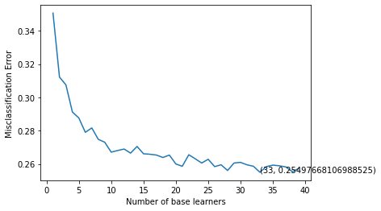

```python
# Finding optimal base learners number
base_ln = [x for x in range(1, 40)]
base_ln

# K-Fold Cross - validation .
cv_scores = []
for b in base_ln:
    clf = RandomForestClassifier(n_estimators = b)
    scores = cross_val_score(clf, CV_X_train, CV_y_train, cv = 5, scoring = 'accuracy')
    cv_scores.append(scores.mean())

# plotting the error as k increases
#error corresponds to each number of estimator
error = [1 - x for x in cv_scores]
#Selection of optimal number of n_estimator corresponds to minimum error.
optimal_learners = base_ln[error.index(min(error))]
#Plot between each number of estimator and misclassification error
plt.plot(base_ln, error)
xy = (optimal_learners, min(error))
plt.annotate('(%s, %s)' % xy, xy = xy, textcoords='data')
plt.xlabel("Number of base learners")
plt.ylabel("Misclassification Error")
plt.show()
```

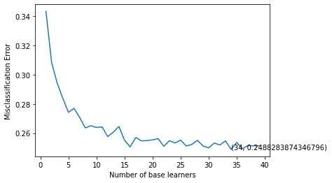

```python
# Finding optimal base learners number
base_ln = [x for x in range(1, 40)]
base_ln

# K-Fold Cross - validation .
TV_scores = []
for b in base_ln:
    clf = RandomForestClassifier(n_estimators = b)
    scores = cross_val_score(clf, TV_X_train, TV_y_train, cv = 5, scoring = 'accuracy')
    TV_scores.append(scores.mean())

# plotting the error as k increases
#error corresponds to each number of estimator
error = [1 - x for x in TV_scores]
#Selection of optimal number of n_estimator corresponds to minimum error.
optimal_learners = base_ln[error.index(min(error))]
#Plot between each number of estimator and misclassification error
plt.plot(base_ln, error)
xy = (optimal_learners, min(error))
plt.annotate('(%s, %s)' % xy, xy = xy, textcoords='data')
plt.xlabel("Number of base learners")
plt.ylabel("Misclassification Error")
plt.show()
```

```python
# Instantiate Random Forest for CountVectorizer
CVForest = RandomForestClassifier(n_estimators=5, n_jobs=4)
CVForest = CVForest.fit(CV_X_train, CV_y_train)

# Instantiate Random Forest for TfidfVectorizer
TVForest = RandomForestClassifier(n_estimators=15, n_jobs=4)
TVForest = TVForest.fit(TV_X_train, TV_y_train)

print('CountVectorizer performance:', 100*np.mean(cross_val_score(CVForest, CV_features, sentiment, cv=10)))
print()
print('TF-IDFVectorizer performance:', 100*np.mean(cross_val_score(TVForest, TV_features, sentiment, cv=10)))
```

```
CountVectorizer performance: 68.26502732240438

TF-IDFVectorizer performance: 70.1775956284153
```

```python
# Instantiate Random Forest for CountVectorizer
CVForest = RandomForestClassifier(n_estimators=13, n_jobs=4)
CVForest = CVForest.fit(CV_X_train, CV_y_train)

# Instantiate Random Forest for TfidfVectorizer
TVForest = RandomForestClassifier(n_estimators=11, n_jobs=4)
TVForest = TVForest.fit(TV_X_train, TV_y_train)

print('CountVectorizer performance:', 100*np.mean(cross_val_score(CVForest, CV_features, sentiment, cv=10)))
print()
print('TF-IDFVectorizer performance:', 100*np.mean(cross_val_score(TVForest, TV_features, sentiment, cv=10)))
```

```
CountVectorizer performance: 70.42349726775956

TF-IDFVectorizer performance: 69.93169398907104
```

```python
# Instantiate Random Forest for CountVectorizer
CVForest = RandomForestClassifier(n_estimators=23, n_jobs=4)
CVForest = CVForest.fit(CV_X_train, CV_y_train)

# Instantiate Random Forest for TfidfVectorizer
TVForest = RandomForestClassifier(n_estimators=25, n_jobs=4)
TVForest = TVForest.fit(TV_X_train, TV_y_train)

print('CountVectorizer performance:', 100*np.mean(cross_val_score(CVForest, CV_features, sentiment, cv=10)))
print()
print('TF-IDFVectorizer performance:', 100*np.mean(cross_val_score(TVForest, TV_features, sentiment, cv=10)))
```

```
CountVectorizer performance: 70.44398907103825

TF-IDFVectorizer performance: 70.1912568306011
```

```
[[2393  230  115]
 [ 434  408  105]
 [ 193  117  397]]
f1-score:  0.7281420765027321
```

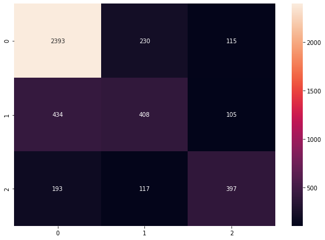

```python
result = CVForest.predict(CV_X_test)
conf_mat = confusion_matrix(CV_y_test, result)
print(conf_mat)

print("f1-score: ",metrics.f1_score(CV_y_test, result,average='micro'))

df_cm = pd.DataFrame(conf_mat, index = [i for i in range(0,3)],
                  columns = [i for i in range(0,3)])
plt.figure(figsize = (10,7))
sns.heatmap(df_cm, annot=True, fmt='g')
```

```
[[2557  126   55]
 [ 525  344   78]
 [ 270   94  343]]
f1-score:  0.738615664845173
```

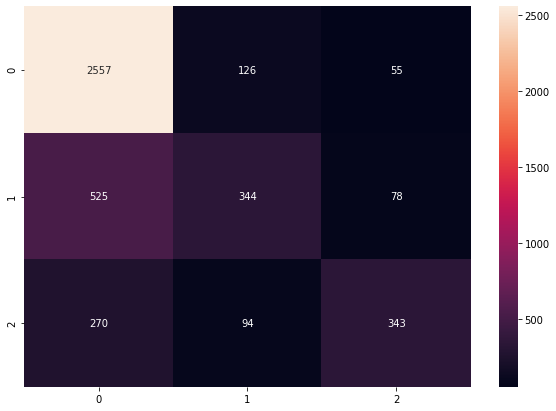

```python
result = TVForest.predict(TV_X_test)
conf_mat = confusion_matrix(TV_y_test, result)
print(conf_mat)

print("f1-score: ",metrics.f1_score(TV_y_test, result,average='micro'))

df_cm = pd.DataFrame(conf_mat, index = [i for i in range(0,3)],
                  columns = [i for i in range(0,3)])
plt.figure(figsize = (10,7))
sns.heatmap(df_cm, annot=True, fmt='g')
```

**Observations & Insights:** I was able to get the best accuracy by increasing the Number of N_estimators to 23 and 25 for CountVectorizer and TfidfVectorizer, respectively. Both models performed very very well at about 73% and 74%, CountVectorizer and TfidfVectorizer, respectively.

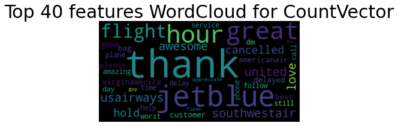

```python
#Get the feature from the CV vectorizer
all_features = CV_features_vector.get_feature_names()
Top_features = ''
feat = CVForest.feature_importances_

features = np.argsort(feat)[::-1]
# cycle and add features to string
for i in features[0:40]:
    Top_features+=all_features[i]
    Top_features+=' '

wordcloud = WordCloud(background_color="Black").generate(Top_features)

# Display the generated image:
plt.imshow(wordcloud, interpolation='bilinear')
plt.figure(1, figsize=(30, 30), frameon='equal')
plt.title('Top 40 features WordCloud for CountVector', fontsize=30)
plt.axis("off")
plt.show()
```

**Observations & Insights:** Using countVector, the top 40 features reveal that the the factors most impacting sentiment show a tendency for the words: 'thank', 'hour', 'usairways' and 'great.

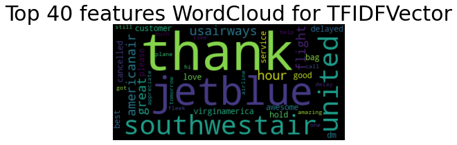

```python
#Get the feature from the CV vectorizer
all_features = TV_features_vector.get_feature_names()
Top_features=''
feat = TVForest.feature_importances_

features = np.argsort(feat)[::-1]
# cycle and add features to string
for i in features[0:40]:
    Top_features+=all_features[i]
    Top_features+=' '


wordcloud = WordCloud(background_color="Black").generate(Top_features)

# Display the generated image:
plt.imshow(wordcloud, interpolation='bilinear')
plt.figure(1, figsize=(30, 30), frameon='equal')
plt.title('Top 40 features WordCloud for TFIDFVector', fontsize=30)
plt.axis("off")
plt.show()
```

**Observations & Insights:** Using TFIDFVector, the top 40 features reveal that the the factors most impacting sentiment show a tendency for the words: 'thank', 'jetblue', 'usairways', 'united', and 'southwestair'.

### Summarize your understanding of the application of Various Pre-processing and Vectorization and the performance of your model on this dataset

While the data captured was unstructured as we would expect from a service like Twitter, we can preprocess our data with a four-phase process to be able to prep it for Vectorization.

The first is to break down the simple elements available to us with BeautifulSoup & RegEx packages such as HTML tags, HTTPS:// weblinks, numbers. We can use an additional package called contractions to expand out works like don’t, haven’t to do not, have not.

The second phase is to ‘tokenize’ our text into various strings for further processing. This is important because this objectifies each word as a unique instance to be able to standardize ASCII, remove punctuation, convert to lowercase and finally, remove stop words that add no value to meaning. This could not be done if each word was not a unique element instead of a continuous string.

The third phase is to Lemmatize the words to ensure the words are broken down even more to remote grammar and just keep the essence or root of each word.

The final process is to stitch the unique elements into continuous strings again and then replace the content of where it previously was.

Once the four phases are complete, we can move onto Vectorization. As for performance, CountVectorizer and TFIDFVectorizer did not have much of an impact on accuracy of the Random Forest. This may be a result of the data sample provided.